# import data use sql, manipulate and clean data, visualization : using python, caculate moving average using excel

# Correlation

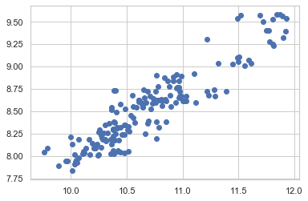

```python
import matplotlib
import matplotlib.pyplot as plt
%matplotlib inline

plt.scatter(df_ma["Seoul_AM"],df_ma["Global_AM"])
```

```python
df_ma.corr(method='pearson')
```

|  | year | Country_temp | Global_temp | Seoul_AM | Global_AM |
| --- | --- | --- | --- | --- | --- |
| year | 1.000000 | 0.678746 | 0.867911 | 0.769750 | 0.796723 |
| Country_temp | 0.678746 | 1.000000 | 0.710788 | 0.605872 | 0.646042 |
| Global_temp | 0.867911 | 0.710788 | 1.000000 | 0.795725 | 0.821953 |
| Seoul_AM | 0.769750 | 0.605872 | 0.795725 | 1.000000 | 0.923418 |
| Global_AM | 0.796723 | 0.646042 | 0.821953 | 0.923418 | 1.000000 |

##### => seoul temperature and global terperature have strong positive relationsip

## My city: Seoul temperature

# What were your key considerations when deciding how to visualize the trends?

##### Line char would be better because it demonstrate the trend according to years

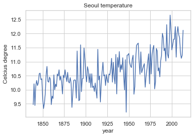

```python
sns.lineplot(df_ma["year"],df_ma["Country_temp"])
plt.title("Seoul temperature")
plt.ylabel("Celcius degree")
```

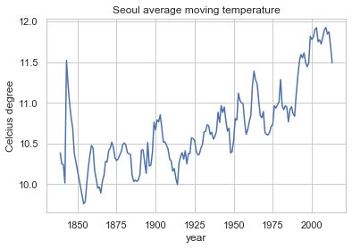

```python
sns.lineplot(df_ma["year"],df_ma["Seoul_AM"])
plt.title("Seoul average moving temperature")
plt.ylabel("Celcius degree")
```

## Compare with Global temperature

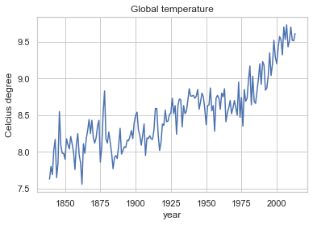

```python
sns.lineplot(df_ma["year"],df_ma["Global_temp"])
plt.title("Global temperature")
plt.ylabel("Celcius degree")
```

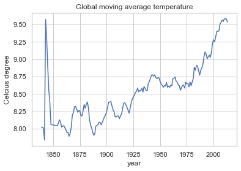

```python
sns.lineplot(df_ma["year"],df_ma["Global_AM"])
plt.title("Global moving average temperature")
plt.ylabel("Celcius degree")
```

# Combine

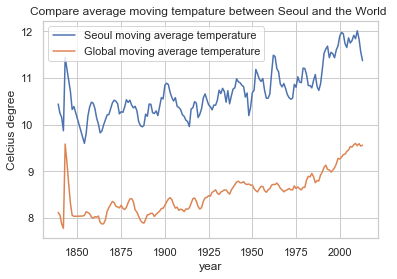

```python
#Combine
sns.lineplot(df_ma["year"],df_ma["Seoul_AM"])
sns.lineplot(df_ma["year"],df_ma["Global_AM"])
plt.legend(labels=["Seoul moving average temperature","Global moving average temperature"],loc="upper left")
plt.ylabel("Celcius degree")
plt.title("Compare average moving tempature between Seoul and the World ")
```

# Observations

## 1) Is your city hotter or cooler on average compared to the global average? Has the difference been consistent over time?

My city is much hotter than the global temperature, the maximum temperature of my city is almost 12, while the maximum temperature the of the global is around 10and the minimum temparature of the my city is about 9, while the minimum temperature of global is around 7.5

## 2) How do the changes in your city’s temperatures over time compare to the changes in the global average?

my city has many small,steep and peaky hills compared to the global temperature, which has flatter hills

## 4) Same

From the correlation, scatter plot we see that seoul and global temperature has the the strong correlationshiop in low temperature

# Favorite city around the world

```python
country.head()
```

|  | year | country_x | city | avg_temp |
| --- | --- | --- | --- | --- |
| 0 | 1849 | Côte D'Ivoire | Abidjan | 25.58 |
| 1 | 1850 | Côte D'Ivoire | Abidjan | 25.52 |
| 2 | 1851 | Côte D'Ivoire | Abidjan | 25.67 |
| 3 | 1852 | Côte D'Ivoire | Abidjan | NaN |
| 4 | 1853 | Côte D'Ivoire | Abidjan | NaN |

```python
df1=country.groupby("country_x")["avg_temp"].mean()
df1
```

```
country_x
Afghanistan                           14.360950
Albania                               15.498202
Algeria                               16.433218
Angola                                23.693649
Argentina                             17.055535
Armenia                                8.365648
Australia                             15.863724
Austria                                8.004794
Azerbaijan                            11.099806
Bahamas                               24.754978
Bahrain                               25.843195
Bangladesh                            25.474085
Belarus                                5.360075
Belgium                                9.850599
Bolivia                                8.735157
Bosnia And Herzegovina                 9.047079
Botswana                              18.992548
Brazil                                21.388041
Bulgaria                               8.429363
Burkina Faso                          28.049167
Burundi                               20.803688
Cameroon                              24.613784
Canada                                 6.159089
Central African Republic              24.944730
Chile                                  8.450528
China                                 12.680495
Colombia                              24.291642
Congo                                 23.861014
Congo (Democratic Republic Of The)    22.273793
Croatia                                9.452285
                                        ...
Sierra Leone                          26.577688
Singapore                             26.522733
Slovakia                               9.838951
Slovenia                               9.452285
Somalia                               27.150851
South Africa                          17.209522
South Korea                           10.684800
Spain                                 15.274921
```

[output cut: 8 more lines]

```
Thailand                              27.154263
Tunisia                               18.424850
Turkey                                14.170389
Uganda                                23.231702
Ukraine                                6.994082
United Arab Emirates                  26.569497
United Kingdom                         8.867865
United States                         14.085249
Uruguay                               16.232286
Uzbekistan                            10.315055
Venezuela                             25.788913
Vietnam                               24.370776
Zambia                                20.427535
Zimbabwe                              20.202183
Name: avg_temp, Length: 135, dtype: float64
```

# Favorite cities:hanoi , ho chi minh city from vietnam

```python
fav=country[country["country_x"]=="Vietnam" ]
fav1=fav[fav["city"]=="Hanoi"]
fav1
```

|  | year | country_x | city | avg_temp |
| --- | --- | --- | --- | --- |
| 26293 | 1840 | Vietnam | Hanoi | 21.00 |
| 26294 | 1841 | Vietnam | Hanoi | 21.30 |
| 26295 | 1842 | Vietnam | Hanoi | 21.16 |
| 26296 | 1843 | Vietnam | Hanoi | 21.26 |
| 26297 | 1844 | Vietnam | Hanoi | 20.78 |
| 26298 | 1845 | Vietnam | Hanoi | 20.68 |
| 26299 | 1846 | Vietnam | Hanoi | 21.25 |
| 26300 | 1847 | Vietnam | Hanoi | 20.83 |
| 26301 | 1848 | Vietnam | Hanoi | 20.73 |
| 26302 | 1849 | Vietnam | Hanoi | 20.94 |
| 26303 | 1850 | Vietnam | Hanoi | 21.11 |
| 26304 | 1851 | Vietnam | Hanoi | 21.26 |
| 26305 | 1852 | Vietnam | Hanoi | 21.12 |
| 26306 | 1853 | Vietnam | Hanoi | 21.51 |
| 26307 | 1854 | Vietnam | Hanoi | 21.45 |
| 26308 | 1855 | Vietnam | Hanoi | 21.10 |
| 26309 | 1856 | Vietnam | Hanoi | 20.69 |
| 26310 | 1857 | Vietnam | Hanoi | 20.89 |
| 26311 | 1858 | Vietnam | Hanoi | 21.10 |
| 26312 | 1859 | Vietnam | Hanoi | 21.24 |
| 26313 | 1860 | Vietnam | Hanoi | 21.12 |
| 26314 | 1861 | Vietnam | Hanoi | 20.95 |
| 26315 | 1862 | Vietnam | Hanoi | 20.48 |
| 26316 | 1863 | Vietnam | Hanoi | 20.90 |
| 26317 | 1864 | Vietnam | Hanoi | 20.77 |
| 26318 | 1865 | Vietnam | Hanoi | 21.41 |
| 26319 | 1866 | Vietnam | Hanoi | 21.24 |
| 26320 | 1867 | Vietnam | Hanoi | 21.40 |
| 26321 | 1868 | Vietnam | Hanoi | 21.53 |
| 26322 | 1869 | Vietnam | Hanoi | 21.18 |
| ... | ... | ... | ... | ... |
| 26437 | 1984 | Vietnam | Hanoi | 21.36 |
| 26438 | 1985 | Vietnam | Hanoi | 21.46 |
| 26439 | 1986 | Vietnam | Hanoi | 21.90 |
| 26440 | 1987 | Vietnam | Hanoi | 22.71 |
| 26441 | 1988 | Vietnam | Hanoi | 21.78 |
| 26442 | 1989 | Vietnam | Hanoi | 21.72 |
| 26443 | 1990 | Vietnam | Hanoi | 22.23 |
| 26444 | 1991 | Vietnam | Hanoi | 22.16 |
| 26445 | 1992 | Vietnam | Hanoi | 21.49 |
| 26446 | 1993 | Vietnam | Hanoi | 21.75 |
| 26447 | 1994 | Vietnam | Hanoi | 21.98 |
| 26448 | 1995 | Vietnam | Hanoi | 21.51 |
| 26449 | 1996 | Vietnam | Hanoi | 21.32 |
| 26450 | 1997 | Vietnam | Hanoi | 21.92 |
| 26451 | 1998 | Vietnam | Hanoi | 22.65 |
| 26452 | 1999 | Vietnam | Hanoi | 22.07 |
| 26453 | 2000 | Vietnam | Hanoi | 21.80 |
| 26454 | 2001 | Vietnam | Hanoi | 21.79 |
| 26455 | 2002 | Vietnam | Hanoi | 22.13 |
| 26456 | 2003 | Vietnam | Hanoi | 22.62 |
| 26457 | 2004 | Vietnam | Hanoi | 21.79 |
| 26458 | 2005 | Vietnam | Hanoi | 21.91 |
| 26459 | 2006 | Vietnam | Hanoi | 22.37 |
| 26460 | 2007 | Vietnam | Hanoi | 22.26 |
| 26461 | 2008 | Vietnam | Hanoi | 21.37 |
| 26462 | 2009 | Vietnam | Hanoi | 22.59 |
| 26463 | 2010 | Vietnam | Hanoi | 22.57 |
| 26464 | 2011 | Vietnam | Hanoi | 21.03 |
| 26465 | 2012 | Vietnam | Hanoi | 22.09 |
| 26466 | 2013 | Vietnam | Hanoi | 23.10 |

174 rows × 4 columns

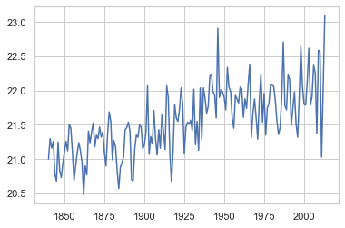

```python
plt.plot(fav1["year"],fav1["avg_temp"])
```

```python
fav=country[country["country_x"]=="Vietnam" ]
fav2=fav[fav["city"]=="Ho Chi Minh City"].dropna()
fav2
```

|  | year | country_x | city | avg_temp |
| --- | --- | --- | --- | --- |
| 27660 | 1825 | Vietnam | Ho Chi Minh City | 27.11 |
| 27674 | 1839 | Vietnam | Ho Chi Minh City | 26.69 |
| 27675 | 1840 | Vietnam | Ho Chi Minh City | 26.63 |
| 27676 | 1841 | Vietnam | Ho Chi Minh City | 27.02 |
| 27677 | 1842 | Vietnam | Ho Chi Minh City | 26.87 |
| 27678 | 1843 | Vietnam | Ho Chi Minh City | 26.94 |
| 27679 | 1844 | Vietnam | Ho Chi Minh City | 26.41 |
| 27680 | 1845 | Vietnam | Ho Chi Minh City | 26.12 |
| 27681 | 1846 | Vietnam | Ho Chi Minh City | 26.94 |
| 27682 | 1847 | Vietnam | Ho Chi Minh City | 26.41 |
| 27685 | 1850 | Vietnam | Ho Chi Minh City | 26.65 |
| 27686 | 1851 | Vietnam | Ho Chi Minh City | 26.82 |
| 27687 | 1852 | Vietnam | Ho Chi Minh City | 26.70 |
| 27688 | 1853 | Vietnam | Ho Chi Minh City | 26.87 |
| 27689 | 1854 | Vietnam | Ho Chi Minh City | 26.89 |
| 27690 | 1855 | Vietnam | Ho Chi Minh City | 26.76 |
| 27691 | 1856 | Vietnam | Ho Chi Minh City | 26.53 |
| 27692 | 1857 | Vietnam | Ho Chi Minh City | 26.51 |
| 27693 | 1858 | Vietnam | Ho Chi Minh City | 26.83 |
| 27694 | 1859 | Vietnam | Ho Chi Minh City | 26.88 |
| 27695 | 1860 | Vietnam | Ho Chi Minh City | 26.69 |
| 27696 | 1861 | Vietnam | Ho Chi Minh City | 26.58 |
| 27697 | 1862 | Vietnam | Ho Chi Minh City | 24.85 |
| 27698 | 1863 | Vietnam | Ho Chi Minh City | 26.67 |
| 27699 | 1864 | Vietnam | Ho Chi Minh City | 26.52 |
| 27700 | 1865 | Vietnam | Ho Chi Minh City | 26.89 |
| 27701 | 1866 | Vietnam | Ho Chi Minh City | 26.84 |
| 27702 | 1867 | Vietnam | Ho Chi Minh City | 26.86 |
| 27703 | 1868 | Vietnam | Ho Chi Minh City | 27.06 |
| 27704 | 1869 | Vietnam | Ho Chi Minh City | 26.64 |
| ... | ... | ... | ... | ... |
| 27819 | 1984 | Vietnam | Ho Chi Minh City | 27.43 |
| 27820 | 1985 | Vietnam | Ho Chi Minh City | 27.64 |
| 27821 | 1986 | Vietnam | Ho Chi Minh City | 27.47 |
| 27822 | 1987 | Vietnam | Ho Chi Minh City | 28.02 |
| 27823 | 1988 | Vietnam | Ho Chi Minh City | 27.79 |
| 27824 | 1989 | Vietnam | Ho Chi Minh City | 27.52 |
| 27825 | 1990 | Vietnam | Ho Chi Minh City | 27.88 |
| 27826 | 1991 | Vietnam | Ho Chi Minh City | 27.71 |
| 27827 | 1992 | Vietnam | Ho Chi Minh City | 27.64 |
| 27828 | 1993 | Vietnam | Ho Chi Minh City | 27.50 |
| 27829 | 1994 | Vietnam | Ho Chi Minh City | 27.60 |
| 27830 | 1995 | Vietnam | Ho Chi Minh City | 27.65 |
| 27831 | 1996 | Vietnam | Ho Chi Minh City | 27.43 |
| 27832 | 1997 | Vietnam | Ho Chi Minh City | 27.80 |
| 27833 | 1998 | Vietnam | Ho Chi Minh City | 28.39 |
| 27834 | 1999 | Vietnam | Ho Chi Minh City | 27.45 |
| 27835 | 2000 | Vietnam | Ho Chi Minh City | 27.59 |
| 27836 | 2001 | Vietnam | Ho Chi Minh City | 27.83 |
| 27837 | 2002 | Vietnam | Ho Chi Minh City | 28.06 |
| 27838 | 2003 | Vietnam | Ho Chi Minh City | 27.83 |
| 27839 | 2004 | Vietnam | Ho Chi Minh City | 27.69 |
| 27840 | 2005 | Vietnam | Ho Chi Minh City | 27.88 |
| 27841 | 2006 | Vietnam | Ho Chi Minh City | 28.04 |
| 27842 | 2007 | Vietnam | Ho Chi Minh City | 27.87 |
| 27843 | 2008 | Vietnam | Ho Chi Minh City | 27.61 |
| 27844 | 2009 | Vietnam | Ho Chi Minh City | 27.85 |
| 27845 | 2010 | Vietnam | Ho Chi Minh City | 28.28 |
| 27846 | 2011 | Vietnam | Ho Chi Minh City | 27.68 |
| 27847 | 2012 | Vietnam | Ho Chi Minh City | 28.25 |
| 27848 | 2013 | Vietnam | Ho Chi Minh City | 28.46 |

174 rows × 4 columns

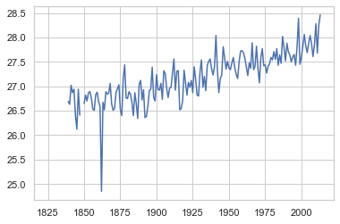

```python
plt.plot(fav2["year"],fav2["avg_temp"])
```

```python
fav1.to_csv("Hanoi.csv",index=False)
```

```python
fav2.to_csv("HCM.csv",index=False)
```

```python
fav1=pd.read_csv("Hanoi.csv").dropna()
fav1
```

|  | year | country_x | city | avg_temp | ma |
| --- | --- | --- | --- | --- | --- |
| 5 | 1845 | Vietnam | Hanoi | 20.68 | 21.100 |
| 6 | 1846 | Vietnam | Hanoi | 21.25 | 21.036 |
| 7 | 1847 | Vietnam | Hanoi | 20.83 | 21.026 |
| 8 | 1848 | Vietnam | Hanoi | 20.73 | 20.960 |
| 9 | 1849 | Vietnam | Hanoi | 20.94 | 20.854 |
| 10 | 1850 | Vietnam | Hanoi | 21.11 | 20.886 |
| 11 | 1851 | Vietnam | Hanoi | 21.26 | 20.972 |
| 12 | 1852 | Vietnam | Hanoi | 21.12 | 20.974 |
| 13 | 1853 | Vietnam | Hanoi | 21.51 | 21.032 |
| 14 | 1854 | Vietnam | Hanoi | 21.45 | 21.188 |
| 15 | 1855 | Vietnam | Hanoi | 21.10 | 21.290 |
| 16 | 1856 | Vietnam | Hanoi | 20.69 | 21.288 |
| 17 | 1857 | Vietnam | Hanoi | 20.89 | 21.174 |
| 18 | 1858 | Vietnam | Hanoi | 21.10 | 21.128 |
| 19 | 1859 | Vietnam | Hanoi | 21.24 | 21.046 |
| 20 | 1860 | Vietnam | Hanoi | 21.12 | 21.004 |
| 21 | 1861 | Vietnam | Hanoi | 20.95 | 21.008 |
| 22 | 1862 | Vietnam | Hanoi | 20.48 | 21.060 |
| 23 | 1863 | Vietnam | Hanoi | 20.90 | 20.978 |
| 24 | 1864 | Vietnam | Hanoi | 20.77 | 20.938 |
| 25 | 1865 | Vietnam | Hanoi | 21.41 | 20.844 |
| 26 | 1866 | Vietnam | Hanoi | 21.24 | 20.902 |
| 27 | 1867 | Vietnam | Hanoi | 21.40 | 20.960 |
| 28 | 1868 | Vietnam | Hanoi | 21.53 | 21.144 |
| 29 | 1869 | Vietnam | Hanoi | 21.18 | 21.270 |
| 30 | 1870 | Vietnam | Hanoi | 21.35 | 21.352 |
| 31 | 1871 | Vietnam | Hanoi | 21.30 | 21.340 |
| 32 | 1872 | Vietnam | Hanoi | 21.47 | 21.352 |
| 33 | 1873 | Vietnam | Hanoi | 21.32 | 21.366 |
| 34 | 1874 | Vietnam | Hanoi | 21.40 | 21.324 |
| ... | ... | ... | ... | ... | ... |
| 144 | 1984 | Vietnam | Hanoi | 21.36 | 21.928 |
| 145 | 1985 | Vietnam | Hanoi | 21.46 | 21.784 |
| 146 | 1986 | Vietnam | Hanoi | 21.90 | 21.660 |
| 147 | 1987 | Vietnam | Hanoi | 22.71 | 21.628 |
| 148 | 1988 | Vietnam | Hanoi | 21.78 | 21.798 |
| 149 | 1989 | Vietnam | Hanoi | 21.72 | 21.842 |
| 150 | 1990 | Vietnam | Hanoi | 22.23 | 21.914 |
| 151 | 1991 | Vietnam | Hanoi | 22.16 | 22.068 |
| 152 | 1992 | Vietnam | Hanoi | 21.49 | 22.120 |
| 153 | 1993 | Vietnam | Hanoi | 21.75 | 21.876 |
| 154 | 1994 | Vietnam | Hanoi | 21.98 | 21.870 |
| 155 | 1995 | Vietnam | Hanoi | 21.51 | 21.922 |
| 156 | 1996 | Vietnam | Hanoi | 21.32 | 21.778 |
| 157 | 1997 | Vietnam | Hanoi | 21.92 | 21.610 |
| 158 | 1998 | Vietnam | Hanoi | 22.65 | 21.696 |
| 159 | 1999 | Vietnam | Hanoi | 22.07 | 21.876 |
| 160 | 2000 | Vietnam | Hanoi | 21.80 | 21.894 |
| 161 | 2001 | Vietnam | Hanoi | 21.79 | 21.952 |
| 162 | 2002 | Vietnam | Hanoi | 22.13 | 22.046 |
| 163 | 2003 | Vietnam | Hanoi | 22.62 | 22.088 |
| 164 | 2004 | Vietnam | Hanoi | 21.79 | 22.082 |
| 165 | 2005 | Vietnam | Hanoi | 21.91 | 22.026 |
| 166 | 2006 | Vietnam | Hanoi | 22.37 | 22.048 |
| 167 | 2007 | Vietnam | Hanoi | 22.26 | 22.164 |
| 168 | 2008 | Vietnam | Hanoi | 21.37 | 22.190 |
| 169 | 2009 | Vietnam | Hanoi | 22.59 | 21.940 |
| 170 | 2010 | Vietnam | Hanoi | 22.57 | 22.100 |
| 171 | 2011 | Vietnam | Hanoi | 21.03 | 22.232 |
| 172 | 2012 | Vietnam | Hanoi | 22.09 | 21.964 |
| 173 | 2013 | Vietnam | Hanoi | 23.10 | 21.930 |

169 rows × 5 columns

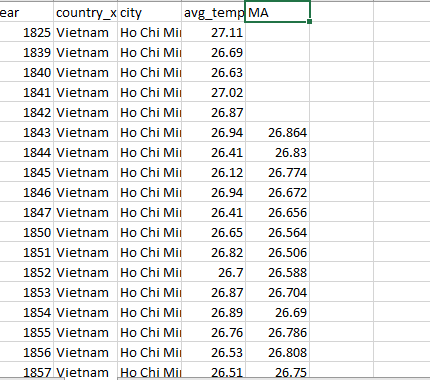

5 year moving average

```python
fav2=pd.read_csv("HCM.csv").dropna()
fav2
```

|  | year | country_x | city | avg_temp | MA |
| --- | --- | --- | --- | --- | --- |
| 5 | 1843 | Vietnam | Ho Chi Minh City | 26.94 | 26.864 |
| 6 | 1844 | Vietnam | Ho Chi Minh City | 26.41 | 26.830 |
| 7 | 1845 | Vietnam | Ho Chi Minh City | 26.12 | 26.774 |
| 8 | 1846 | Vietnam | Ho Chi Minh City | 26.94 | 26.672 |
| 9 | 1847 | Vietnam | Ho Chi Minh City | 26.41 | 26.656 |
| 10 | 1850 | Vietnam | Ho Chi Minh City | 26.65 | 26.564 |
| 11 | 1851 | Vietnam | Ho Chi Minh City | 26.82 | 26.506 |
| 12 | 1852 | Vietnam | Ho Chi Minh City | 26.70 | 26.588 |
| 13 | 1853 | Vietnam | Ho Chi Minh City | 26.87 | 26.704 |
| 14 | 1854 | Vietnam | Ho Chi Minh City | 26.89 | 26.690 |
| 15 | 1855 | Vietnam | Ho Chi Minh City | 26.76 | 26.786 |
| 16 | 1856 | Vietnam | Ho Chi Minh City | 26.53 | 26.808 |
| 17 | 1857 | Vietnam | Ho Chi Minh City | 26.51 | 26.750 |
| 18 | 1858 | Vietnam | Ho Chi Minh City | 26.83 | 26.712 |
| 19 | 1859 | Vietnam | Ho Chi Minh City | 26.88 | 26.704 |
| 20 | 1860 | Vietnam | Ho Chi Minh City | 26.69 | 26.702 |
| 21 | 1861 | Vietnam | Ho Chi Minh City | 26.58 | 26.688 |
| 22 | 1862 | Vietnam | Ho Chi Minh City | 24.85 | 26.698 |
| 23 | 1863 | Vietnam | Ho Chi Minh City | 26.67 | 26.366 |
| 24 | 1864 | Vietnam | Ho Chi Minh City | 26.52 | 26.334 |
| 25 | 1865 | Vietnam | Ho Chi Minh City | 26.89 | 26.262 |
| 26 | 1866 | Vietnam | Ho Chi Minh City | 26.84 | 26.302 |
| 27 | 1867 | Vietnam | Ho Chi Minh City | 26.86 | 26.354 |
| 28 | 1868 | Vietnam | Ho Chi Minh City | 27.06 | 26.756 |
| 29 | 1869 | Vietnam | Ho Chi Minh City | 26.64 | 26.834 |
| 30 | 1870 | Vietnam | Ho Chi Minh City | 26.51 | 26.858 |
| 31 | 1871 | Vietnam | Ho Chi Minh City | 26.54 | 26.782 |
| 32 | 1872 | Vietnam | Ho Chi Minh City | 26.87 | 26.722 |
| 33 | 1873 | Vietnam | Ho Chi Minh City | 26.95 | 26.724 |
| 34 | 1874 | Vietnam | Ho Chi Minh City | 27.03 | 26.702 |
| ... | ... | ... | ... | ... | ... |
| 144 | 1984 | Vietnam | Ho Chi Minh City | 27.43 | 27.632 |
| 145 | 1985 | Vietnam | Ho Chi Minh City | 27.64 | 27.600 |
| 146 | 1986 | Vietnam | Ho Chi Minh City | 27.47 | 27.620 |
| 147 | 1987 | Vietnam | Ho Chi Minh City | 28.02 | 27.572 |
| 148 | 1988 | Vietnam | Ho Chi Minh City | 27.79 | 27.666 |
| 149 | 1989 | Vietnam | Ho Chi Minh City | 27.52 | 27.670 |
| 150 | 1990 | Vietnam | Ho Chi Minh City | 27.88 | 27.688 |
| 151 | 1991 | Vietnam | Ho Chi Minh City | 27.71 | 27.736 |
| 152 | 1992 | Vietnam | Ho Chi Minh City | 27.64 | 27.784 |
| 153 | 1993 | Vietnam | Ho Chi Minh City | 27.50 | 27.708 |
| 154 | 1994 | Vietnam | Ho Chi Minh City | 27.60 | 27.650 |
| 155 | 1995 | Vietnam | Ho Chi Minh City | 27.65 | 27.666 |
| 156 | 1996 | Vietnam | Ho Chi Minh City | 27.43 | 27.620 |
| 157 | 1997 | Vietnam | Ho Chi Minh City | 27.80 | 27.564 |
| 158 | 1998 | Vietnam | Ho Chi Minh City | 28.39 | 27.596 |
| 159 | 1999 | Vietnam | Ho Chi Minh City | 27.45 | 27.774 |
| 160 | 2000 | Vietnam | Ho Chi Minh City | 27.59 | 27.744 |
| 161 | 2001 | Vietnam | Ho Chi Minh City | 27.83 | 27.732 |
| 162 | 2002 | Vietnam | Ho Chi Minh City | 28.06 | 27.812 |
| 163 | 2003 | Vietnam | Ho Chi Minh City | 27.83 | 27.864 |
| 164 | 2004 | Vietnam | Ho Chi Minh City | 27.69 | 27.752 |
| 165 | 2005 | Vietnam | Ho Chi Minh City | 27.88 | 27.800 |
| 166 | 2006 | Vietnam | Ho Chi Minh City | 28.04 | 27.858 |
| 167 | 2007 | Vietnam | Ho Chi Minh City | 27.87 | 27.900 |
| 168 | 2008 | Vietnam | Ho Chi Minh City | 27.61 | 27.862 |
| 169 | 2009 | Vietnam | Ho Chi Minh City | 27.85 | 27.818 |
| 170 | 2010 | Vietnam | Ho Chi Minh City | 28.28 | 27.850 |
| 171 | 2011 | Vietnam | Ho Chi Minh City | 27.68 | 27.930 |
| 172 | 2012 | Vietnam | Ho Chi Minh City | 28.25 | 27.858 |
| 173 | 2013 | Vietnam | Ho Chi Minh City | 28.46 | 27.934 |

169 rows × 5 columns

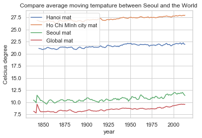

```python
sns.lineplot(fav1["year"],fav1["ma"])
sns.lineplot(fav2["year"],fav2["MA"])
sns.lineplot(df_ma["year"],df_ma["Seoul_AM"])
sns.lineplot(df_ma["year"],df_ma["Global_AM"])

plt.legend(labels=["Hanoi mat ","Ho Chi MInh city mat","Seoul mat","Global mat"],loc="upper left")
plt.ylabel("Celcius degree")
plt.title("Compare average moving tempature between Seoul and the World ")
```

# Observation

my favorite city which are Hanoi and Ho Chi Minh city always have higher average moving temperature than the city I live ,the temperatures are going up but they are really slow compared to the world and Seoul